# Course Introduction

Xijia Liu

Department of Statistics, Umeå University

## Introduction

- Main topic: Non-linear Models
- Artificial Neural Networks, Deep Learning basic.
- Expected Learning outcomes:
  $$\text{Understanding} > \text{Implementation} >0$$

## Course Design

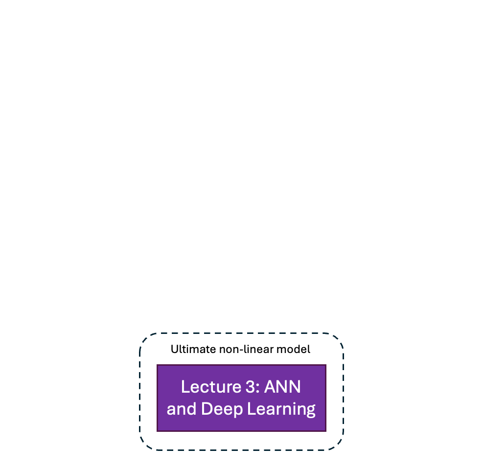

There are many ways to introduce and explain neural networks, most of which require learners to have a certain level of prior knowledge.

## Course Design

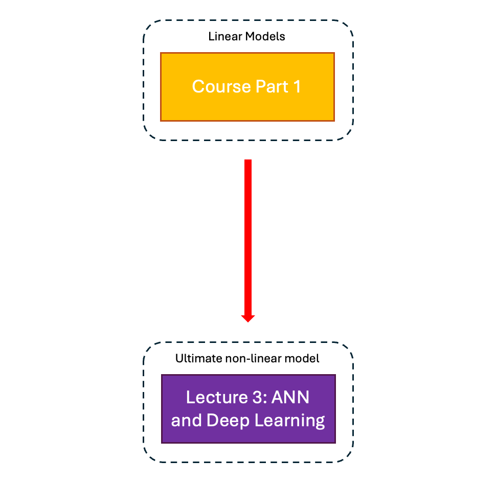

However, how to quickly understand deep learning based on neural network models within a limited time, building on the first part of the course, is a challenge.

## Course Design

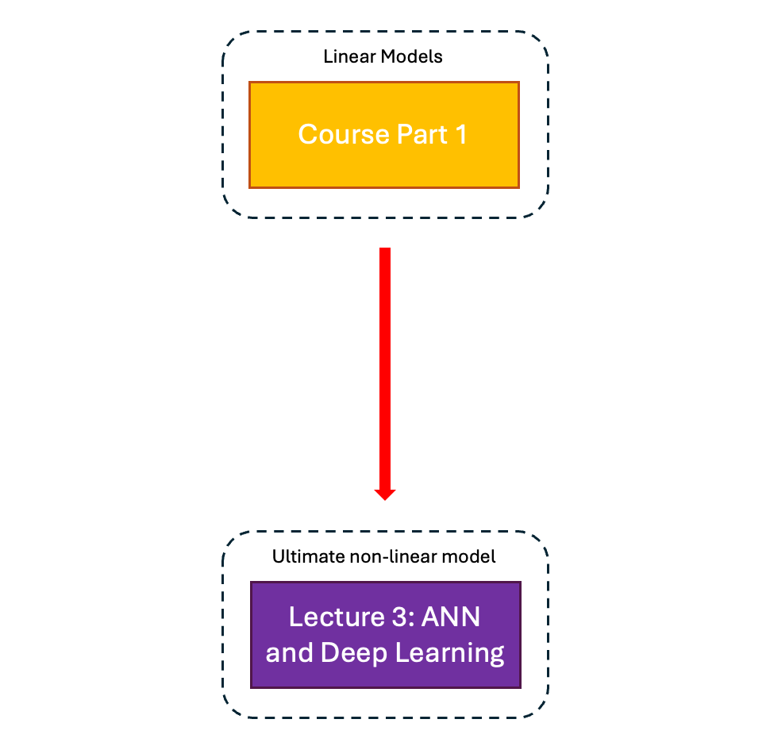

Here, I will use the most cost-effective approach to help you deeply understand neural network models. No free lunches. We first need to take some time to build a bridge.

## Course Design

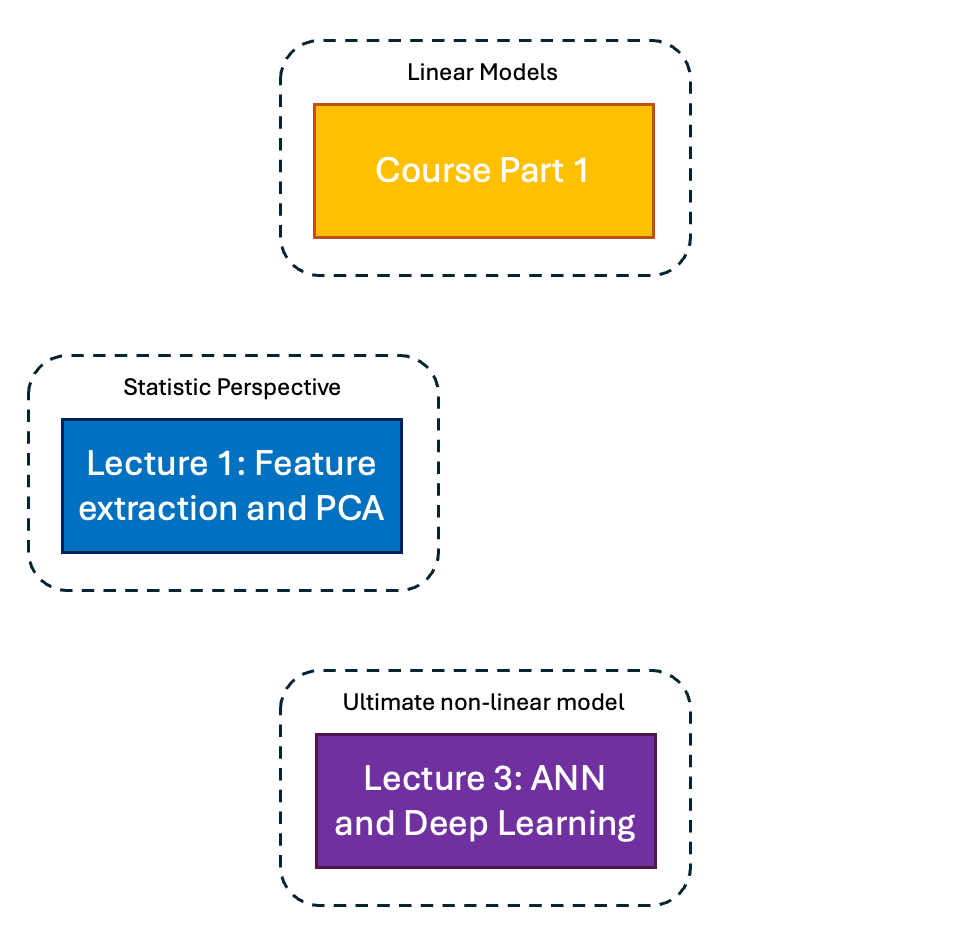

To build this bridge, we will introduce the concept of feature extraction in the first lecture and present the most fundamental data-driven solution, PCA.

## Course Design

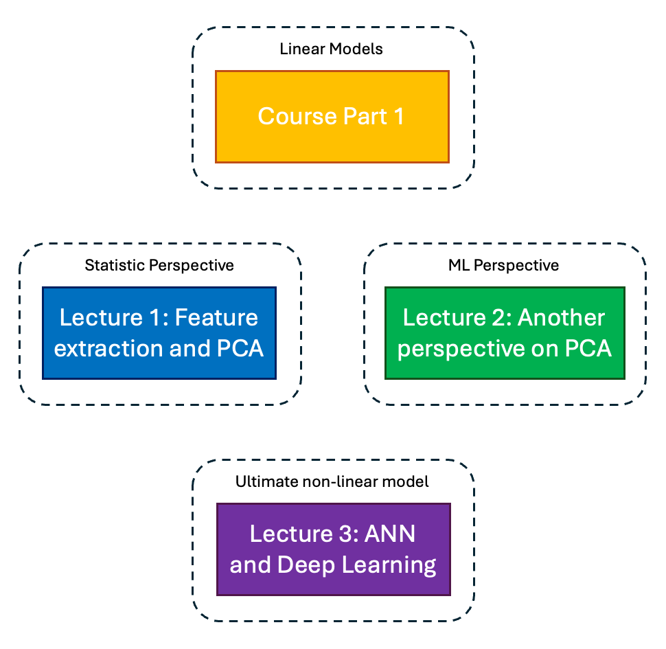

Then, in the second lecture, we will revisit PCA from a machine learning perspective using a practical example.

## Course Design

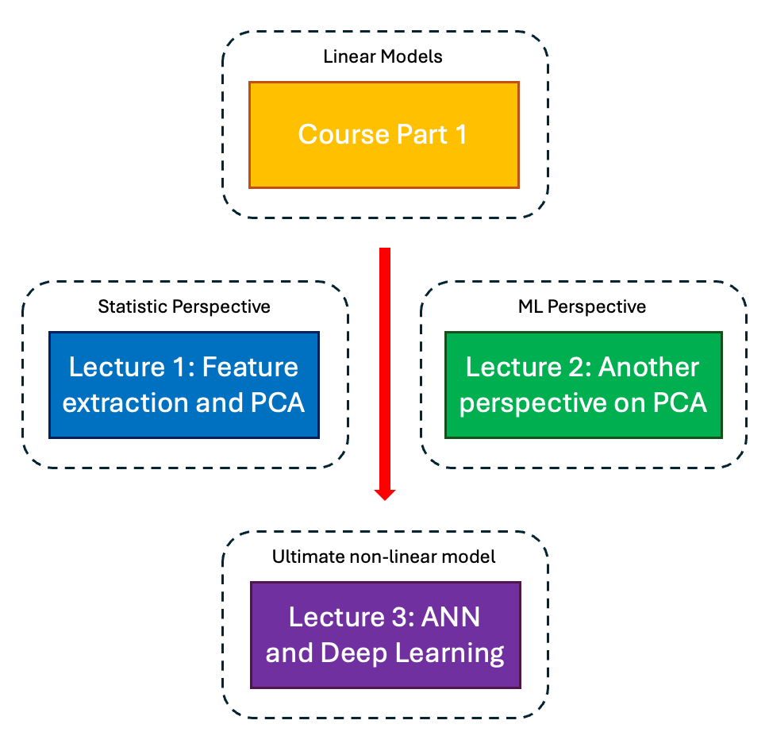

I believe that once you fully understand the content of the first two lectures, you will smoothly grasp ANN models and the core concepts of deep learning.

## Teaching Methods

- Online course + Flipped classroom method
- Read and study learning materials
- Two Zoom meetings. In each meeting,
  1. Discussion and Q/A $\approx 1$ hour.
  2. Lab session $\approx 2$ hours.
- Communication: Canvas messages

## Learning Materials

- Textbook: Introduction to statistical learning with application in R
- My lecture notes and materials on **Yggdrasil**

## Exam (Mandatory)

- Project study
- Maximum two students
- Suggested problems or topics you are interested in
- Oral exam:
  1. Individual meeting on Zoom
  2. Discuss your project study
  3. Other course related questions
- Timetable: check it on Canvas